# Interesting Forecasting Applications with R

Alperen Köksal - IE360 - Fall 2020

1. [Time series forecasting using ARIMA models](https://blogs.oracle.com/datascience/introduction-to-forecasting-with-arima-in-r)

   In this article there are good methods for forecasting in R.

   Here is how to do a seasonal naive forecast:

```r
library(forecast)
library(MLmetrics)
```

```r
data=AirPassengers
#Create samples
training=window(data, start = c(1949,1), end = c(1955,12))
validation=window(data, start = c(1956,1))

naive = snaive(training, h=length(validation))
MAPE(naive$mean, validation) * 100
```

```
## [1] 27.04689
```

```
Here is how to plot the forecast:
```

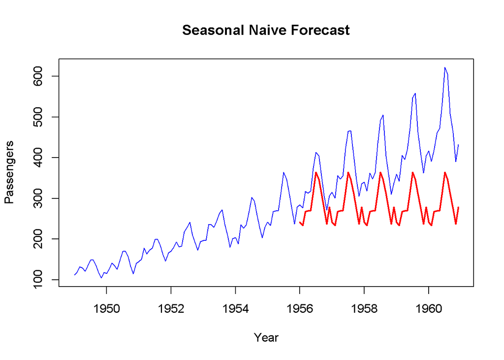

[output not shown]

```r
plot(data, col="blue", xlab="Year", ylab="Passengers", main="Seasonal Naive Forecast", type='l')
lines(naive$mean, col="red", lwd=2)
```

```r
ets_model = ets(training, allow.multiplicative.trend = TRUE)
summary(ets_model)
```

```
## ETS(M,Md,M)
##
## Call:
##  ets(y = training, allow.multiplicative.trend = TRUE)
##
##   Smoothing parameters:
##     alpha = 0.6749
##     beta  = 0.0082
##     gamma = 1e-04
##     phi   = 0.98
##
##   Initial states:
##     l = 119.9101
##     b = 1.0177
##     s = 0.9065 0.7973 0.9184 1.0524 1.1863 1.1987
##            1.0896 0.9798 0.9957 1.046 0.9167 0.9126
##
##   sigma:  0.0395
##
##      AIC     AICc      BIC
## 726.4475 736.9706 770.2022
##
## Training set error measures:
##                     ME     RMSE      MAE       MPE     MAPE      MASE      ACF1
## Training set 0.9845273 7.241276 5.726611 0.2712157 2.907857 0.2145244 0.0453492
```

```r
ets_forecast = forecast(ets_model, h=length(validation))
MAPE(ets_forecast$mean, validation) *100
```

```
## [1] 12.59147
```

3. Double Seasonal Holt-Winters The ets function is good, but it only allows for one seasonality. Sometimes, the data we have can be composed of multiple seasonalities (monthly and yearly for instance). Double Seasonal Holt-Winters (DSHW) allows for two seasonalities: a smaller one repeated often and a bigger one repeated less often. For the method to work however, the seasonalities need to be nested, meaning one must be an integer multiple of the other (2 and 4, 24 and 168, etc.). The code here is a bit different since we need to specify the lenghts of our two seasonalities (which is not always something we know) and the forecast is computed directly when creating the model with the dshw function.

```r
dshw_model = dshw(training, period1=4, period2 = 12, h=length(validation))
MAPE(dshw_model$mean, validation)*100
```

```
## [1] 3.27219
```

4 DSHW is good, but some processes have more complex seasonalities, which our previous functions cannot handle. Indeed, you could have both a weekly and yearly seasonality. You could even have more than 2! BATS and TBATS allow for multiple seasonalities. TBATS is a modification (an improvement really) of BATS that allows for multiple non-integer seasonality cycles. Here is how to build a TBATS model and forecast with it:

```r
tbats_model = tbats(training)
tbats_forecast = forecast(tbats_model, h=length(validation))
MAPE(tbats_forecast$mean, validation) * 100
```

```
## [1] 12.84821
```

The auto.arima function can be used to return the best estimated model. Here is the code:

```r
arima_optimal = auto.arima(training)
```

The function returned the following model: ARIMA(0,1,1)(1,1,0)[12]. To forecast a SARIMA model (which is what we have here since we have a seasonal part), we can use the sarima.for function from the astsa package.

```r
library(astsa)
```

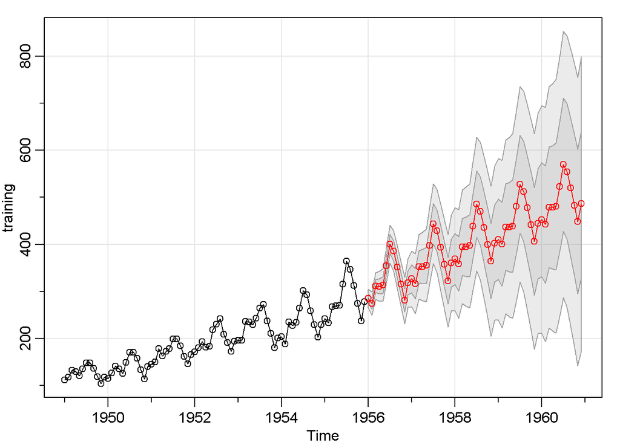

```r
sarima_forecast = sarima.for(training, n.ahead=length(validation),
                              p=0,d=1,q=1,P=1,D=1,Q=0,S=12)
```

```r
MAPE(sarima_forecast$pred, validation) * 100
```

```
## [1] 6.544624
```

```r
one_step_ahead_sarima = matrix(ncol = 2, nrow = 60)
# for (i in 1:60){
#
#   training_observed = window(data, start = c(1949,1), end = c(1955,(12+i)), frequency = 12)
#
#   forecasted.sarima = sarima.for(training_observed,n.ahead=1,p=0,d=1,q=1,P=1,D=1,Q=0,S=12)
#
#   demandforecast = forecasted.sarima$pred
#   observed = validation[[i]]
#
#   one_step_ahead_sarima[i,1]= observed
#   one_step_ahead_sarima[i,2]= demandforecast
# }
# it basically plots 60 graphs of next month
MAPE(one_step_ahead_sarima[,1], one_step_ahead_sarima[,2]) * 100
```

```
## [1] NA
```

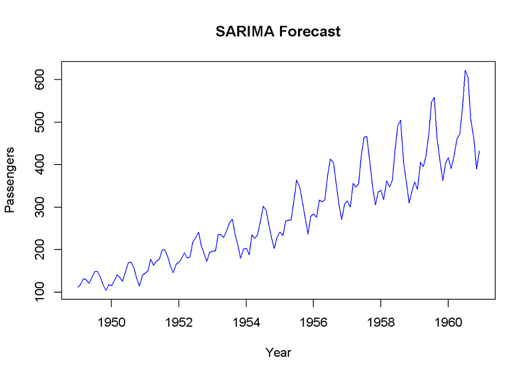

```r
plot(data, col="blue", xlab="Year", ylab="Passengers", main="SARIMA Forecast", type='l')
lines(ts(one_step_ahead_sarima[,2], start = c(1956,1), frequency = 12), col="red", lwd=3)
```